# sci-lianti figures: DNA-RNA coassay (Figure 3)

Yue

3/10/2019

The DNA-RNA coassay figure has its separate Rmd because it takes some time to run, especially the Seurat steps.

```r
if (!is.na(fig_dir)) system(sprintf("mkdir -p %s", fig_dir))
```

# Load data and minor processing

There are two separate libraries, yi244 and yi257, each sequenced at high and low depths. `d(r)na_df` are summary stats tables for each cell.

yi244_q10_save.rda contains the following items:

- use_lo_dna_df
- use_lo_rna_df
- use_hi_dna_df
- use_hi_rna_df
- use_lo_hek_df
- use_lo_bj_df
- use_hi_hek_df
- use_hi_bj_df

yi257_q10_save.rda contains the following items:

- yi257_use_lo_dna_df
- yi257_use_lo_rna_df
- yi257_use_hi_dna_df
- yi257_use_hi_rna_df
- yi257_use_lo_hek_df
- yi257_use_lo_bj_df
- yi257_use_hi_hek_df
- yi257_use_hi_bj_df

In addition, we also have cell $\times$ gene count matrix for RNA. For the two libraries we have `yi244_joint_rna_mtx_q10.rds` and `yi257_joint_rna_mtx_q10.rds`.

## Load stuff

```r
load(slfile("coassay/yi244_q10_save.rda"))
load(slfile("coassay/yi257_q10_save.rda"))
yi244_joint_rna_count <- readRDS(slfile("coassay/yi244_joint_rna_mtx_q10.rds"))
yi257_joint_rna_count <- readRDS(slfile("coassay/yi257_joint_rna_mtx_q10.rds"))
```

## Combine libraries

```r
yi244_yi257_use_hi_bj_df <- bind_rows(use_hi_bj_df, yi257_use_hi_bj_df)
yi244_yi257_use_hi_hek_df <- bind_rows(use_hi_hek_df, yi257_use_hi_hek_df)
yi244_yi257_use_lo_bj_df <- bind_rows(use_lo_bj_df, yi257_use_lo_bj_df)
yi244_yi257_use_lo_hek_df <- bind_rows(use_lo_hek_df, yi257_use_lo_hek_df)

yi244_yi257_use_hi_dna_df <- bind_rows(use_hi_dna_df, yi257_use_hi_dna_df)
yi244_yi257_use_hi_rna_df <- bind_rows(use_hi_rna_df, yi257_use_hi_rna_df)
yi244_yi257_use_lo_dna_df <- bind_rows(use_lo_dna_df, yi257_use_lo_dna_df)
yi244_yi257_use_lo_rna_df <- bind_rows(use_lo_rna_df, yi257_use_lo_rna_df)
```

## Summary stats

```r
yi244_yi257_use_lo_dna_df$dna_genome_hm_r1s %>% median()
```

```
## [1] 18320.5
```

```r
yi244_yi257_use_lo_rna_df$rna_gene_hm_umis %>% median()
```

```
## [1] 64
```

```r
yi244_yi257_use_hi_dna_df$dna_genome_hm_r1s %>% median()
```

```
## [1] 73208.5
```

```r
yi244_yi257_use_hi_rna_df$rna_gene_hm_umis %>% median()
```

```
## [1] 219
```

```r
yi244_yi257_use_lo_dna_df$dna_genome_hm_r1s %>% mean()
```

```
## [1] 38116.38
```

```r
yi244_yi257_use_lo_rna_df$rna_gene_hm_umis %>% mean()
```

```
## [1] 101.9964
```

```r
yi244_yi257_use_hi_dna_df$dna_genome_hm_r1s %>% mean()
```

```
## [1] 154739.1
```

```r
yi244_yi257_use_hi_rna_df$rna_gene_hm_umis %>% mean()
```

```
## [1] 368.7621
```

```r
yi244_yi257_use_lo_rna_df$rna_complexity %>% median()
```

```
## [1] 1.047619
```

```r
yi244_yi257_use_hi_rna_df$rna_complexity %>% median()
```

```
## [1] 1.15625
```

```
## $collision_rate
## [1] 0.04232804
##
## $plot
```

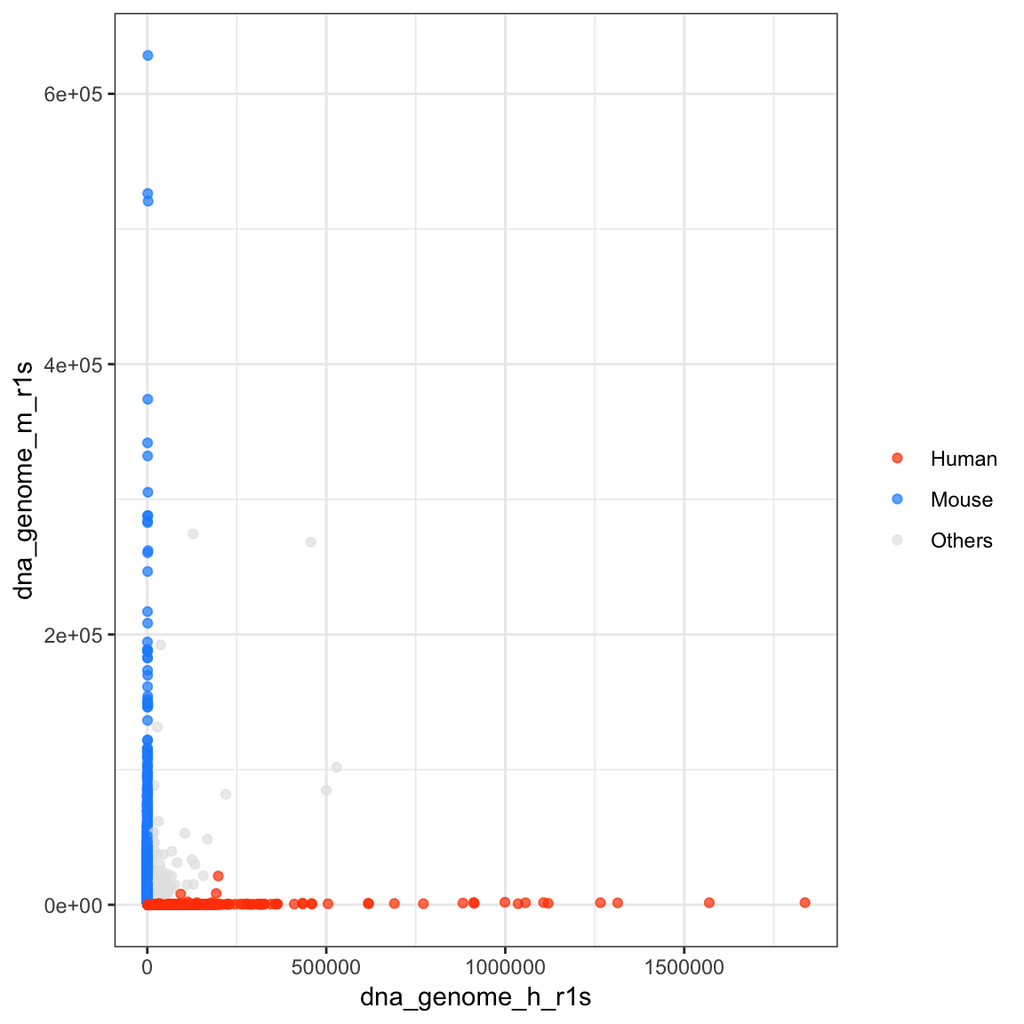

```r
# collision
dna_collision <- function(df) {
  p <- ggplot(df, aes(dna_genome_h_r1s, dna_genome_m_r1s)) +
    geom_point(aes(color=hm), alpha=0.7) +
    scale_color_manual("", values=c("Human"="orangered", "Mouse"="dodgerblue", "Others"="grey90")) +
    theme_bw()
  ret <- list("collision_rate"=mean(df$hm == "Others"),
              "plot"=p)
  ret
}

rna_collision <- function(df) {
  p <- ggplot(df, aes(rna_gene_h_umis, rna_gene_m_umis)) +
    geom_point(aes(color=hm), alpha=0.7) +
    scale_color_manual("", values=c("Human"="orangered", "Mouse"="dodgerblue", "Others"="grey90")) +
    theme_bw()
  ret <- list("collision_rate"=mean(df$hm == "Others"),
              "plot"=p)
  ret
}

dna_collision(yi244_yi257_use_lo_dna_df)
```

```r
dna_collision(yi244_yi257_use_hi_dna_df)
```

```
## $collision_rate
## [1] 0.01851852
##
## $plot
```

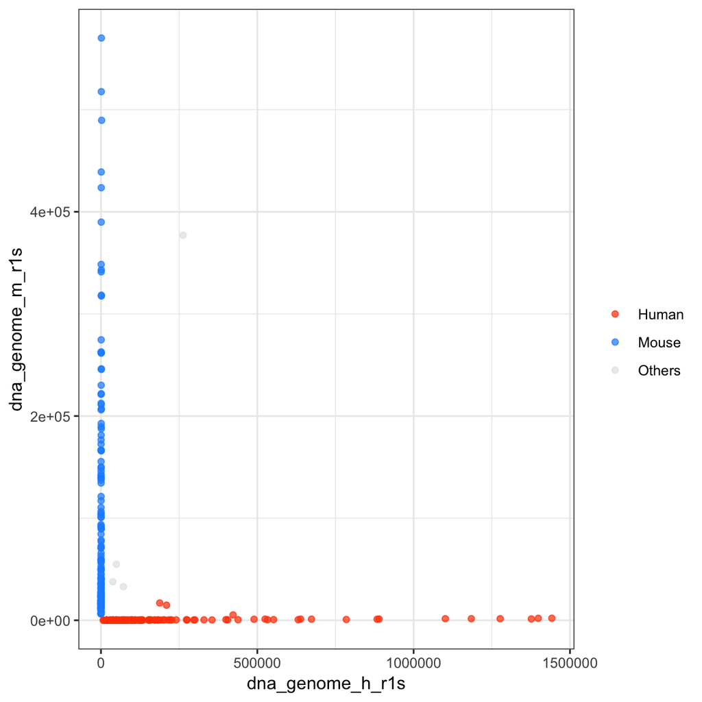

```r
rna_collision(yi244_yi257_use_lo_rna_df)
```

```
## $collision_rate
## [1] 0.07910448
##
## $plot
```

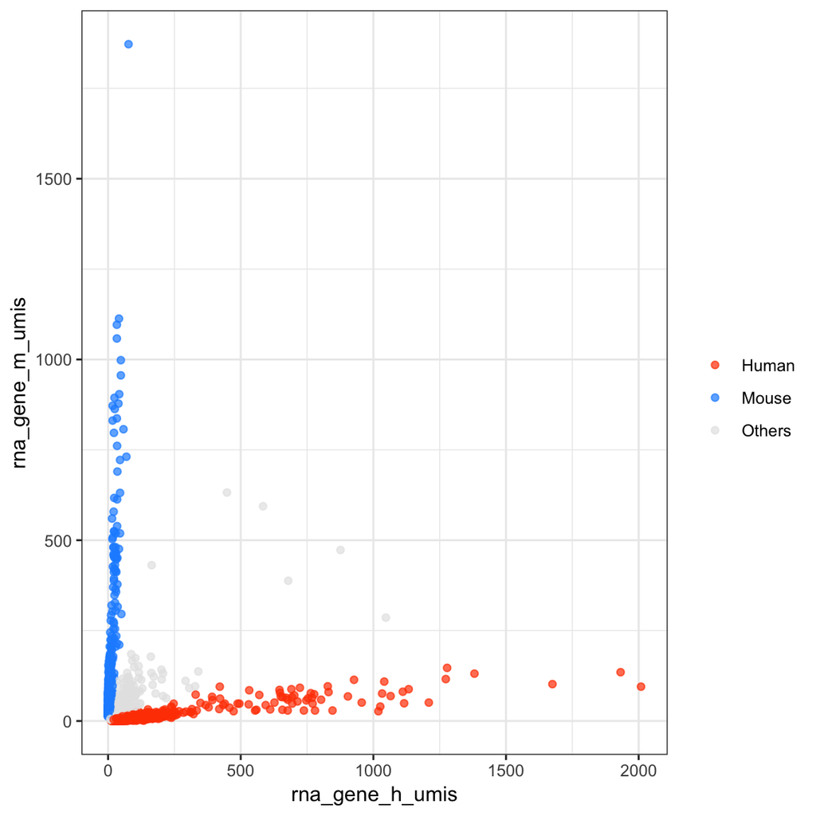

```r
rna_collision(yi244_yi257_use_hi_rna_df)
```

```
## $collision_rate
## [1] 0.0260223
##
## $plot
```

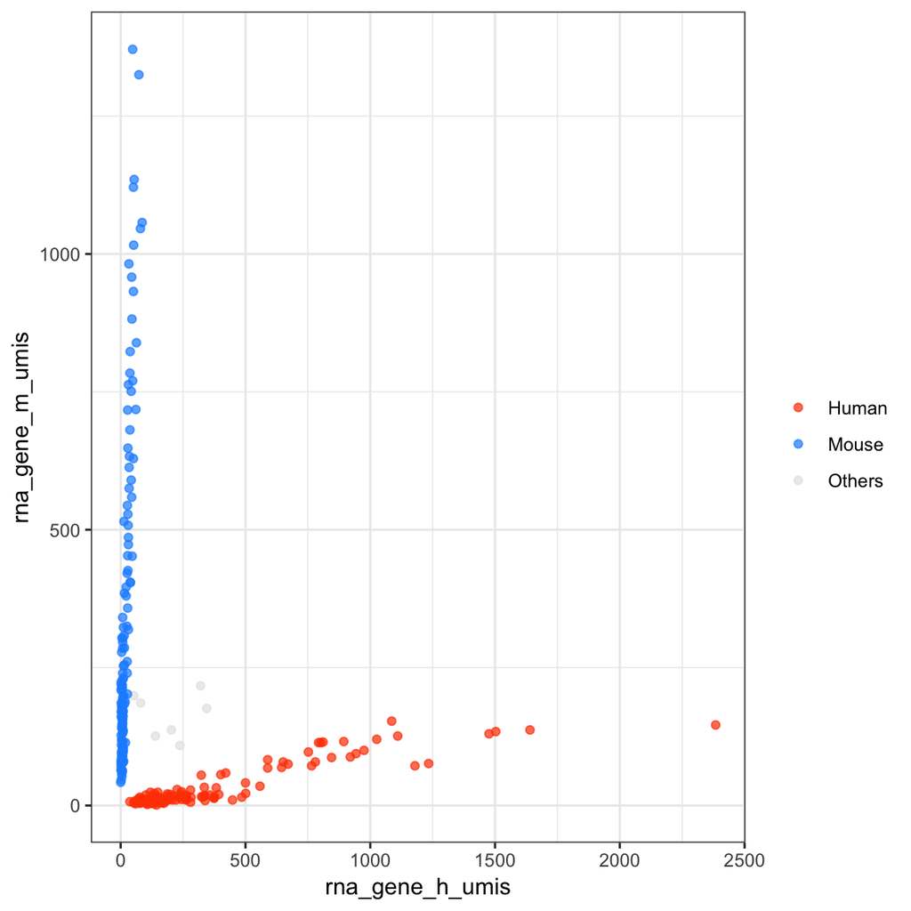

```r
dna_collision(bind_rows(yi244_yi257_use_lo_dna_df, yi244_yi257_use_hi_dna_df))
```

```
## $collision_rate
## [1] 0.04057734
##
## $plot
```

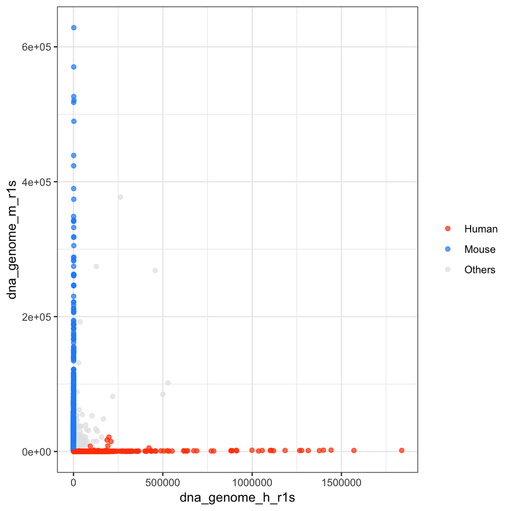

```r
rna_collision(bind_rows(yi244_yi257_use_lo_rna_df, yi244_yi257_use_hi_rna_df))
```

```
## $collision_rate
## [1] 0.07515888
##
## $plot
```

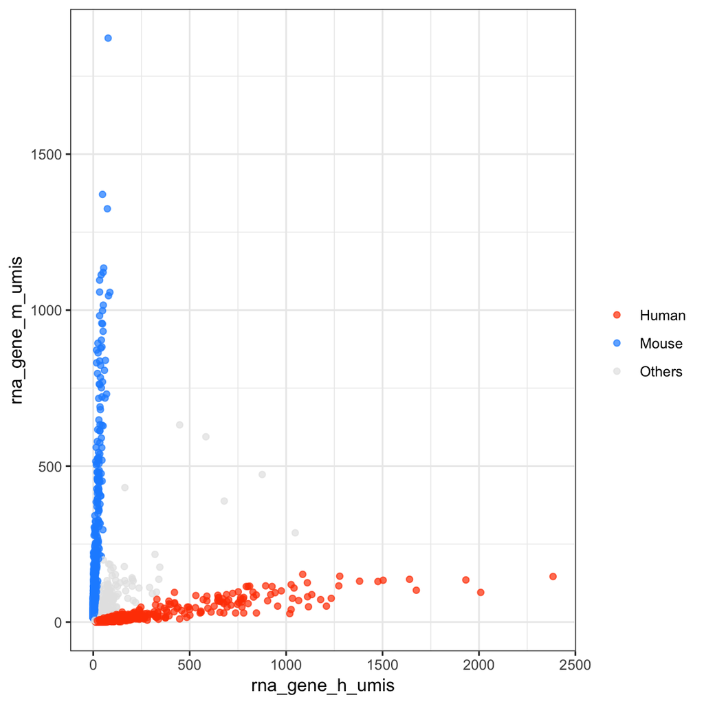

```r
# purity
purity <- function(df) {
  df %>%
    group_by(hm) %>%
    summarise(PURITY=mean(h_rate)) %>%
    mutate(PURITY=case_when(hm == "Mouse" ~ 1 - PURITY,
                            TRUE ~ PURITY))
}
purity(yi244_yi257_use_lo_dna_df)
```

```
## # A tibble: 3 x 2
##   hm     PURITY
##   <chr>   <dbl>
## 1 Human   0.996
## 2 Mouse   0.994
## 3 Others  0.575
```

```r
purity(yi244_yi257_use_lo_rna_df)
```

```
## # A tibble: 3 x 2
##   hm     PURITY
##   <chr>   <dbl>
## 1 Human   0.907
## 2 Mouse   0.936
## 3 Others  0.568
```

```r
purity(yi244_yi257_use_hi_dna_df)
```

```
## # A tibble: 3 x 2
##   hm     PURITY
##   <chr>   <dbl>
## 1 Human   0.997
## 2 Mouse   0.994
## 3 Others  0.475
```

```r
purity(yi244_yi257_use_hi_rna_df)
```

```
## # A tibble: 3 x 2
##   hm     PURITY
##   <chr>   <dbl>
## 1 Human   0.924
## 2 Mouse   0.949
## 3 Others  0.510
```

```r
purity(bind_rows(yi244_yi257_use_lo_dna_df, yi244_yi257_use_hi_dna_df))
```

```
## # A tibble: 3 x 2
##   hm     PURITY
##   <chr>   <dbl>
## 1 Human   0.996
## 2 Mouse   0.994
## 3 Others  0.571
```

```r
purity(bind_rows(yi244_yi257_use_lo_rna_df, yi244_yi257_use_hi_rna_df))
```

```
## # A tibble: 3 x 2
##   hm     PURITY
##   <chr>   <dbl>
## 1 Human   0.908
## 2 Mouse   0.937
## 3 Others  0.567
```

# Fig 3C

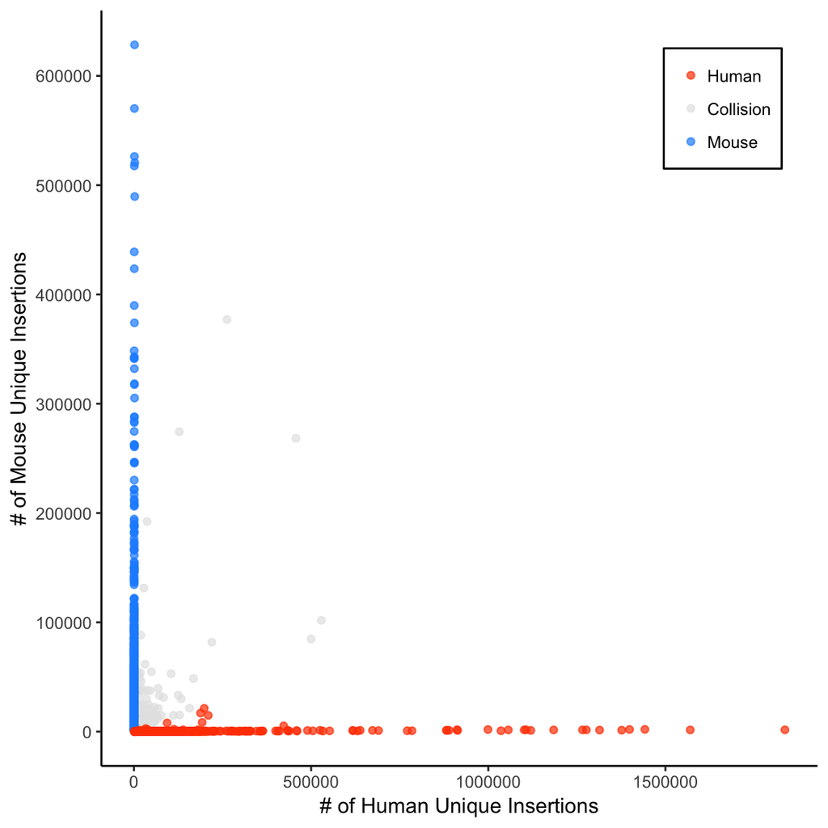

```r
p <- yi244_yi257_use_hi_dna_df %>%
  bind_rows(yi244_yi257_use_lo_dna_df) %>%
  mutate(hm=case_when(hm == "Others" ~ "Collision",
                      TRUE ~ hm)) %>%
  mutate(hm=factor(hm, levels=c("Human", "Mouse", "Collision"))) %>%
  arrange(desc(hm)) %>%
  mutate(hm=factor(hm, levels=c("Human", "Collision", "Mouse"))) %>%
  ggplot(aes(dna_genome_h_r1s, dna_genome_m_r1s)) +
  geom_point(aes(color=hm), alpha=0.7) +
  scale_color_manual("", values=c("Human"="orangered", "Mouse"="dodgerblue", "Collision"="grey90")) +
  scale_x_continuous(labels=scales::format_format(scientific = FALSE),
                     breaks=scales::pretty_breaks(n=5)) +
  scale_y_continuous(labels=scales::format_format(scientific = FALSE),
                     breaks=scales::pretty_breaks(n=5)) +
  xlab("# of Human Unique Insertions") +
  ylab("# of Mouse Unique Insertions") +
  theme_classic() +
  theme(legend.title=element_blank(),
        legend.justification=c(1, 1),
        legend.position=c(0.95, 0.95),
        legend.background=element_rect(colour="black", size=0.5),
        axis.line = element_line(colour = "black"),
        panel.grid.major = element_blank(),
        panel.grid.minor = element_blank(),
        panel.border = element_blank(),
        panel.background = element_blank())
p
```

```r
ggsave("fig3C.pdf", p, "pdf", fig_dir, height=2.5, width=3)
```

# Fig 3D

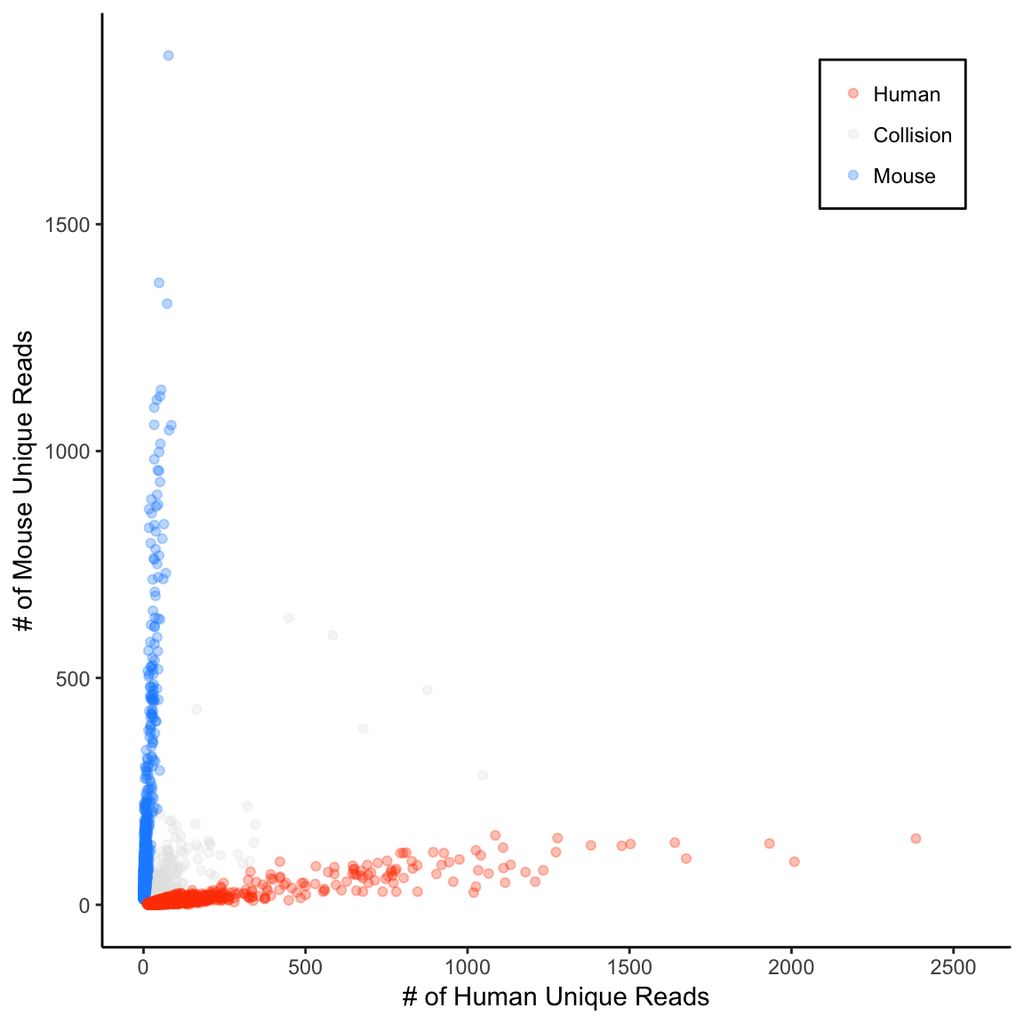

```r
p <- yi244_yi257_use_hi_rna_df %>%
  bind_rows(yi244_yi257_use_lo_rna_df) %>%
  mutate(hm=case_when(hm == "Others" ~ "Collision",
                      TRUE ~ hm)) %>%
  mutate(hm=factor(hm, levels=c("Human", "Mouse", "Collision"))) %>%
  arrange(desc(hm)) %>%
  mutate(hm=factor(hm, levels=c("Human", "Collision", "Mouse"))) %>%
  ggplot(aes(rna_gene_h_umis, rna_gene_m_umis)) +
  geom_point(aes(color=hm), alpha=0.3) +
  scale_color_manual("", values=c("Human"="orangered", "Collision"="grey90", "Mouse"="dodgerblue")) +
  scale_x_continuous(labels=scales::format_format(scientific = FALSE),
                     breaks=scales::pretty_breaks(n=5), limits = c(0, 2550)) +
  scale_y_continuous(labels=scales::format_format(scientific = FALSE),
                     breaks=scales::pretty_breaks(n=5)) +
  xlab("# of Human Unique Reads") +
  ylab("# of Mouse Unique Reads") +
  theme_classic() +
  theme(legend.title=element_blank(),
        legend.justification=c(1, 1),
        legend.position=c(0.95, 0.95),
        legend.background=element_rect(colour="black", size=0.5),
        axis.line = element_line(colour = "black"),
        panel.grid.major = element_blank(),
        panel.grid.minor = element_blank(),
        panel.border = element_blank(),
        panel.background = element_blank())
p
```

```r
ggsave("fig3D.pdf", p, "pdf", fig_dir, height=2.5, width=2.7)
```

# Human cell clustering

Merge RNA count tables of human cells (BJ mixed with HEK) and prepare for Seurat clustering.

```r
yi244_hek_bj_count <- yi244_joint_rna_count[colnames(yi244_joint_rna_count) %in% c(
  "GENE",
  use_lo_hek_df$CELL_RNA, use_hi_hek_df$CELL_RNA, use_lo_bj_df$CELL_RNA, use_hi_bj_df$CELL_RNA
)]
colnames(yi244_hek_bj_count)[2:ncol(yi244_hek_bj_count)] <- paste0(colnames(yi244_hek_bj_count)[2:ncol(yi244_hek_bj_count)], "yi244")

yi257_hek_bj_count <- yi257_joint_rna_count[colnames(yi257_joint_rna_count) %in% c(
  "GENE",
  yi257_use_lo_hek_df$CELL_RNA, yi257_use_hi_hek_df$CELL_RNA, yi257_use_lo_bj_df$CELL_RNA, yi257_use_hi_bj_df$CELL_RNA
)]
colnames(yi257_hek_bj_count)[2:ncol(yi257_hek_bj_count)] <- paste0(colnames(yi257_hek_bj_count)[2:ncol(yi257_hek_bj_count)], "yi257")

yi244_yi257_hek_bj_count <- full_join(yi244_hek_bj_count, yi257_hek_bj_count, by="GENE")
mtx <- as.matrix(yi244_yi257_hek_bj_count[, -1])
mtx[is.na(mtx)] <- 0
rownames(mtx) <- yi244_yi257_hek_bj_count$GENE
h_gene_idx <- which(yi244_yi257_hek_bj_count$GENE == toupper(yi244_yi257_hek_bj_count$GENE))
h_mtx <- mtx[h_gene_idx, ]
smtx <- Matrix(h_mtx, sparse=TRUE)
```

## Default Seurat workflow

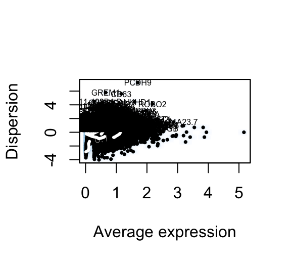

```r
seu <- CreateSeuratObject(raw.data = smtx, min.cells = 2, min.genes = 50, project = "coassay")
mito.genes <- grep(pattern = "^MT-", x = rownames(x = seu@data), value = TRUE)
percent.mito <- Matrix::colSums(seu@raw.data[mito.genes, ])/Matrix::colSums(seu@raw.data)
seu <- AddMetaData(object = seu, metadata = percent.mito, col.name = "percent.mito")

# VlnPlot(object = seu, features.plot = c("nGene", "nUMI", "percent.mito"), nCol = 3)
# GenePlot(object = seu, gene1 = "nUMI", gene2 = "percent.mito")
# GenePlot(object = seu, gene1 = "nUMI", gene2 = "nGene")

seu <- NormalizeData(object = seu, normalization.method = "LogNormalize",
    scale.factor = 10000)
seu <- FindVariableGenes(object = seu, mean.function = ExpMean, dispersion.function = LogVMR,
    x.low.cutoff = 0.0125, x.high.cutoff = 3, y.cutoff = 0.5)
```

```r
# length(x = seu@var.genes)

seu <- ScaleData(object = seu, vars.to.regress = c("nUMI", "percent.mito"))
```

```
##
## Time Elapsed:  6.53348684310913 secs
```

```r
seu <- RunPCA(object = seu, pc.genes = seu@var.genes, do.print = TRUE, pcs.print = 1:5,
    genes.print = 5)
```

```
## [1] "PC1"
## [1] "RP6-24A23.7" "PCDH7"       "AUTS2"       "CREB5"       "LRP1B"
## [1] ""
## [1] "RP11-269F21.3" "PTRF"          "FN1"           "TNFRSF11B"
## [5] "AXL"
## [1] ""
## [1] ""
## [1] "PC2"
## [1] "HRSP12"  "KIFC3"   "PROSER1" "BAG4"    "SSBP4"
## [1] ""
## [1] "PI4KB"      "UBE2I"      "PGM2"       "AC144521.1" "NANS"
## [1] ""
## [1] ""
## [1] "PC3"
## [1] "AC004538.3" "SPEG"       "ATP10D"     "SREBF1"     "AHSA2"
```

[output cut: 18 more lines]

```r
# PCAPlot(object = seu, dim.1 = 1, dim.2 = 2)
# PCHeatmap(object = seu, pc.use = 1:12, do.balanced = TRUE, label.columns = FALSE, use.full = FALSE)

seu <- JackStraw(object = seu, num.replicate = 100, display.progress = FALSE)

# JackStrawPlot(object = seu, PCs = 1:12)
# PCElbowPlot(object = seu)

seu <- FindClusters(object = seu, reduction.type = "pca", dims.use = 1:10,
    resolution = 0.6, print.output = 0, save.SNN = TRUE)

# PrintFindClustersParams(object = seu)

seu <- RunTSNE(object = seu, dims.use = 1:10, do.fast = F)

# TSNEPlot(object = seu)
# PCAPlot(object=seu)

seu_df <- seu@dr$tsne@cell.embeddings %>%
  as.data.frame() %>%
  rownames_to_column("CELL") %>%
  left_join(GetClusters(seu), by=c("CELL"="cell.name")) %>%
  mutate(TYPE=case_when(CELL %in% c(paste0(use_lo_hek_df$CELL_RNA, "yi244"),
                                    paste0(use_hi_hek_df$CELL_RNA, "yi244")) ~ "HEK_244",
                        CELL %in% c(paste0(yi257_use_lo_hek_df$CELL_RNA, "yi257"),
                                    paste0(yi257_use_hi_hek_df$CELL_RNA, "yi257")) ~ "HEK_257",
                        CELL %in% c(paste0(use_lo_bj_df$CELL_RNA, "yi244"),
                                    paste0(use_hi_bj_df$CELL_RNA, "yi244")) ~ "BJ_244",
                        CELL %in% c(paste0(yi257_use_lo_bj_df$CELL_RNA, "yi257"),
                                    paste0(yi257_use_hi_bj_df$CELL_RNA, "yi257")) ~ "BJ_257",
                        TRUE ~ "Others"))

dplyr::count(seu_df, gsub("_.*", "", TYPE), cluster)
```

```
## # A tibble: 4 x 3
##   `gsub("_.*", "", TYPE)` cluster     n
##   <chr>                   <fct>   <int>
## 1 BJ                      0          26
## 2 BJ                      1         170
## 3 HEK                     0         818
## 4 HEK                     1          10
```

## Fig 3E

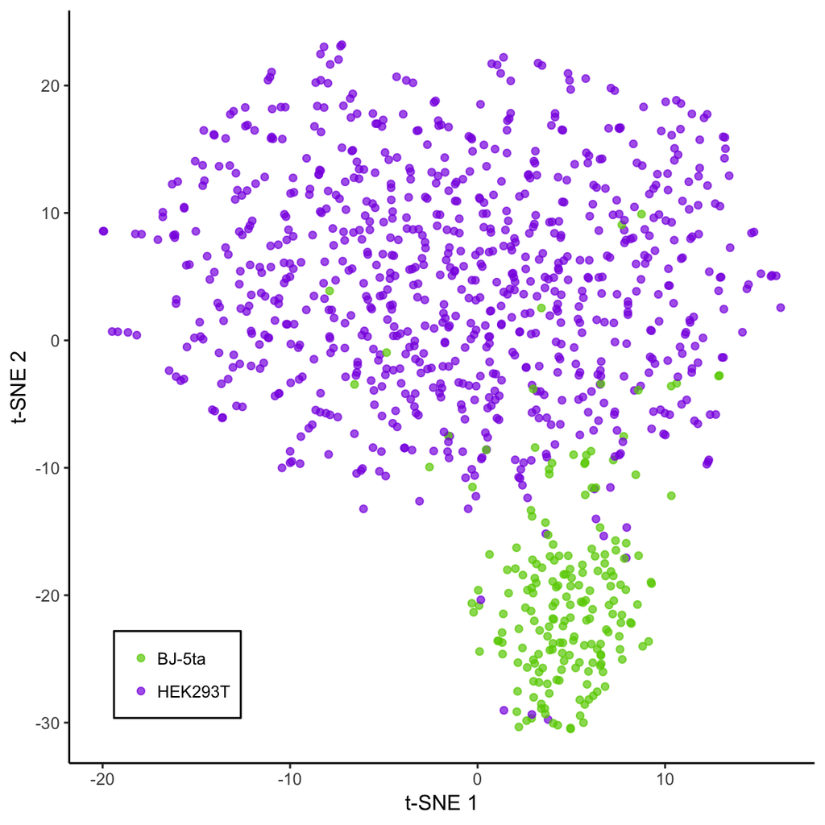

```r
p <- seu_df %>%
  mutate(TYPE2=case_when(grepl("BJ", TYPE) ~ "BJ-5ta",
                         grepl("HEK", TYPE) ~ "HEK293T")) %>%
  ggplot(aes(tSNE_1, tSNE_2)) +
  geom_point(aes(color=TYPE2), alpha=0.7) +
  scale_color_manual("", values=c("BJ-5ta"="chartreuse3", "HEK293T"="blueviolet")) +
  xlab("t-SNE 1") +
  ylab("t-SNE 2") +
  theme_classic() +
  theme(legend.title=element_blank(),
        legend.justification=c(0, 0),
        legend.position=c(0.06, 0.06),
        legend.background=element_rect(colour="black", size=0.5),
        axis.line = element_line(colour = "black"),
        panel.grid.major = element_blank(),
        panel.grid.minor = element_blank(),
        panel.border = element_blank(),
        panel.background = element_blank())
p
```

```r
ggsave("fig3E.pdf", p, "pdf", fig_dir, height=3.8, width=4)
```